# Adding levels of randomness

## Maximum posterior

```r
library(rstan)
(fit <- optimizing(bb_model,  # stan model from above
                   data=list(N=10, Z=6)))
```

```
## $par
##     theta
## 0.5208333
##
## $value
## [1] -33.22939
##
## $return_code
## [1] 0
##
## $theta_tilde
##          theta
## [1,] 0.5208333
```

## The answer!

The *maximum a posteriori probability estimate* (MAP) is 0.5208333.

```r
post_fun <- function (p) {
    n <- 10; z <- 6; a <- b <- 20
    lik <- dbinom(z, size=n, prob=p)
    prior <- dbeta(p, a, b)
    return( prior * lik )
}
curve(post_fun, 0, 1, xlab=expression(theta), ylab='posterior prob')
points(fit$par, post_fun(fit$par), col='red', pch=20)
```

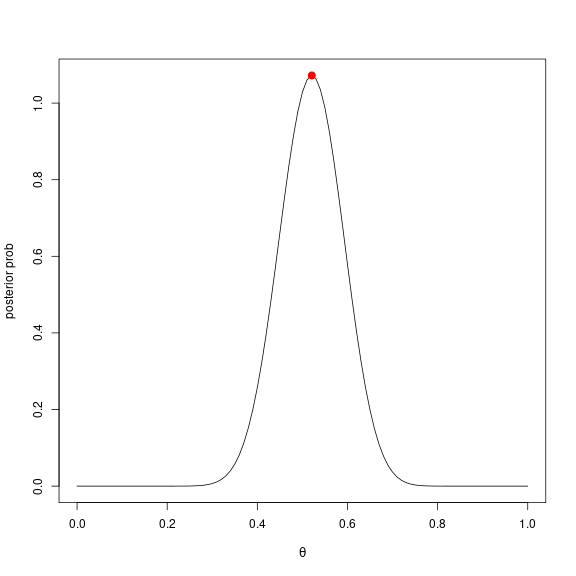

## Sampling from the posterior distribution

```r
library(rstan)
fit <- sampling(bb_model,  # compiled stan model from above
                data=list(N=10, Z=6),
                chains=3, iter=10000)
```

`lp__` is the log posterior density. Note `n_eff` and `Rhat`.

```r
print(fit)
```

```
## Inference for Stan model: 5f3115ac9593cded393e67d2d0e3ce84.
## 3 chains, each with iter=10000; warmup=5000; thin=1;
## post-warmup draws per chain=5000, total post-warmup draws=15000.
##
##         mean se_mean   sd   2.5%    25%    50%    75%  97.5% n_eff Rhat
## theta   0.52    0.00 0.07   0.38   0.47   0.52   0.57   0.66  6136    1
## lp__  -35.12    0.01 0.71 -37.17 -35.28 -34.85 -34.67 -34.62  5608    1
##
## Samples were drawn using NUTS(diag_e) at Mon Nov 15 21:07:21 2021.
## For each parameter, n_eff is a crude measure of effective sample size,
## and Rhat is the potential scale reduction factor on split chains (at
## convergence, Rhat=1).
```

Fuzzy caterpillars are good.

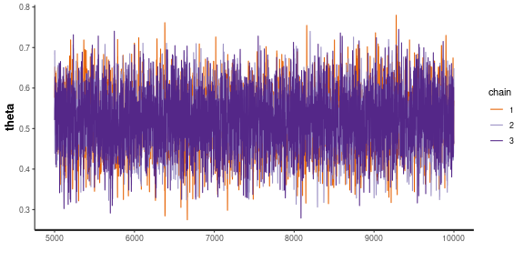

```r
stan_trace(fit)
```

Stan uses ggplot2.

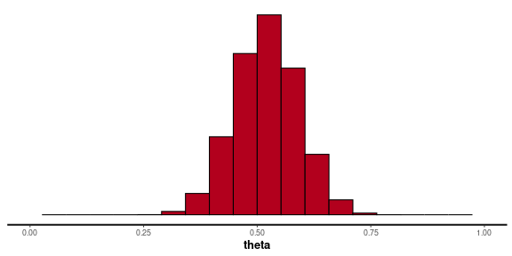

```r
stan_hist(fit, bins=20) + xlim(0,1)
```

The *samples*:

```r
sampled_theta <- extract(fit, permuted=FALSE, inc_warmup=TRUE)
```

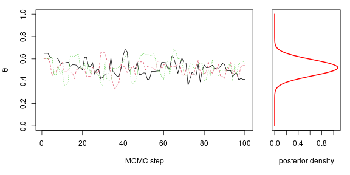

What’s the posterior probability that $\theta < 0.5$?

```r
samples <- extract(fit)
mean(samples$theta < 0.5)
```

```
## [1] 0.384
```

```r
# compare to analytic solution
pbeta(0.5, shape1=20+6, shape2=20+4)
```

```
## [1] 0.3877248
```

# Hierarchical Coins

$$\begin{aligned}
Z_i &\sim \Binom(N_i, \theta_i) \\
\theta_i &\sim \Beta(\alpha, \beta) \\
\alpha &\sim \Unif(0, 100) \\
\beta &\sim \Unif(0, 100)
\end{aligned}$$

```
data {
    // the data (input)
}
parameters {
    // the parameters (output)
}
model {
    // how they are related
}
```

$$\begin{aligned}
Z_i &\sim \Binom(N_i, \theta_i) \\
\theta_i &\sim \Beta(\alpha, \beta) \\
\alpha &\sim \Unif(0, 100) \\
\beta &\sim \Unif(0, 100)
\end{aligned}$$

```
data {
    int n;      // number of coins
    int N[n];   // number of flips
    int Z[n];   // number of heads
}
parameters {
    // the parameters (output)
}
model {
    // how they are related
}
```

$$\begin{aligned}
Z_i &\sim \Binom(N_i, \theta_i) \\
\theta_i &\sim \Beta(\alpha, \beta) \\
\alpha &\sim \Unif(0, 100) \\
\beta &\sim \Unif(0, 100)
\end{aligned}$$

```
data {
    int n;      // number of coins
    int N[n];   // number of flips
    int Z[n];   // number of heads
}
parameters {
    // probability of heads
    real<lower=0,upper=1> theta[n];
    real<lower=0,upper=100> alpha;
    real<lower=0,upper=100> beta;
}
model {
    // how they are related
}
```

$$\begin{aligned}
Z_i &\sim \Binom(N_i, \theta_i) \\
\theta_i &\sim \Beta(\alpha, \beta) \\
\alpha &\sim \Unif(0, 100) \\
\beta &\sim \Unif(0, 100)
\end{aligned}$$

```
data {
    int n;      // number of coins
    int N[n];   // number of flips
    int Z[n];   // number of heads
}
parameters {
    // probability of heads
    real<lower=0,upper=1> theta[n];
    real<lower=0, upper=100> alpha;
    real<lower=0, upper=100> beta;
}
model {
    Z ~ binomial(N, theta);
    theta ~ beta(alpha, beta);
    // uniform priors "go without saying"
    // alpha ~ uniform(0, 100);
    // beta ~ uniform(0, 100);
}
```

## Exercise

Data:

```
set.seed(23)
ncoins <- 100
true_theta <- rbeta(ncoins, 20, 50)
N <- rep(50, ncoins)
Z <- rbinom(ncoins, size=N, prob=true_theta)
```

Find the posterior distribution on `alpha` and `beta`: check convergence with `print()` and `stan_trace()`, then plot using `stan_hist()`, `pairs()`, and/or `stan_scat()` (with e.g., `pars=c("alpha", "beta", "theta[1]", "theta[2]")`).

```
data {
    int n;      // number of coins
    int N[n];   // number of flips
    int Z[n];   // number of heads
}
parameters {
    // probability of heads
    real<lower=0,upper=1> theta[n];
    real<lower=0,upper=100> alpha;
    real<lower=0,upper=100> beta;
}
model {
    Z ~ binomial(N, theta);
    theta ~ beta(alpha, beta);
    // uniform priors 'go without saying'
    // alpha ~ uniform(0, 100);
    // beta ~ uniform(0, 100);
}
```

## IN CLASS

```r
model_code <- "
data {
    int n;      // number of coins
    int N[n];   // number of flips
    int Z[n];   // number of heads
}
parameters {
    // probability of heads
    real<lower=0,upper=1> theta[n];
    real<lower=0,upper=100> alpha;
    real<lower=0,upper=100> beta;
}
model {
    Z ~ binomial(N, theta);
    theta ~ beta(alpha, beta);
    // uniform priors 'go without saying'
    // alpha ~ uniform(0, 100);
    // beta ~ uniform(0, 100);
}
"
model <- stan_model(model_code=model_code)
```

## data:

```r
set.seed(23)
ncoins <- 100
true_theta <- rbeta(ncoins, 20, 50)
N <- rep(50, ncoins)
Z <- rbinom(ncoins, size=N, prob=true_theta)
```

## fit mmmodel

```r
fit1 <- sampling(model,
         data=list(N=N, Z=Z, n=ncoins),
         chains=3, iter=1000)
fit2 <- sampling(model,
         data=list(N=N, Z=Z, n=ncoins),
         chains=3, iter=5000)
```

## plot trace

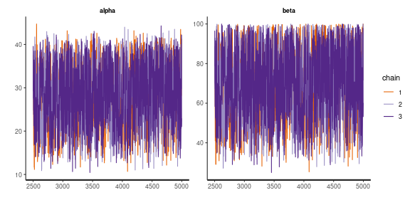

```r
stan_trace(fit2, pars=c("alpha", "beta"))
```

## look at results

Note the posterior intervals for `alpha` and `beta`:

```r
rstan::summary(fit2)$summary
```

```
##                     mean      se_mean          sd          2.5%           25%           50%           75%         97.5%     n_eff      Rhat
## theta[1]       0.2917988 0.0004125683  0.03779479     0.2211084     0.2661861     0.2907644     0.3160459     0.3700863 8392.1310 0.9998365
## theta[2]       0.2581785 0.0004120545  0.03704161     0.1879117     0.2325430     0.2578913     0.2825079     0.3332164 8081.1009 1.0000029
## theta[3]       0.3065083 0.0004536602  0.03886474     0.2344475     0.2795073     0.3055743     0.3318121     0.3863964 7339.2248 1.0000731
## theta[4]       0.2851268 0.0004214931  0.03821356     0.2129591     0.2585586     0.2844941     0.3102555     0.3603522 8219.6637 1.0002799
## theta[5]       0.2571079 0.0004446583  0.03672410     0.1867113     0.2321856     0.2561545     0.2816435     0.3295946 6821.0259 0.9997497
## theta[6]       0.3270950 0.0004603358  0.04010376     0.2523229     0.2995214     0.3257214     0.3533930     0.4091024 7589.6286 0.9998880
## theta[7]       0.2992070 0.0004153123  0.03810265     0.2275179     0.2728440     0.2980592     0.3243058     0.3769895 8417.0662 0.9998509
## theta[8]       0.2922524 0.0003978970  0.03824006     0.2214836     0.2660296     0.2904321     0.3173091     0.3702462 9236.2518 0.9999761
## theta[9]       0.2639424 0.0004116463  0.03707327     0.1939021     0.2378778     0.2632794     0.2887504     0.3395545 8110.9801 1.0002949
## theta[10]      0.2713837 0.0004104860  0.03684887     0.1995005     0.2465886     0.2712412     0.2959662     0.3437765 8058.4545 0.9997515
## theta[11]      0.2919100 0.0004198478  0.03805388     0.2201065     0.2663409     0.2912990     0.3165783     0.3683227 8215.1243 1.0000383
## theta[12]      0.2643035 0.0003818231  0.03686586     0.1954648     0.2391527     0.2628249     0.2890451     0.3397814 9322.3309 0.9997950
## theta[13]      0.2915575 0.0004187071  0.03726929     0.2208711     0.2663372     0.2901505     0.3172342     0.3663520 7922.8532 0.9997019
## theta[14]      0.2501941 0.0004474661  0.03684892     0.1797143     0.2254120     0.2492363     0.2752540     0.3255106 6781.5558 0.9996698
## theta[15]      0.2511710 0.0004257149  0.03696623     0.1800006     0.2267502     0.2502266     0.2751937     0.3277070 7540.0210 0.9997739
## theta[16]      0.2724192 0.0004118264  0.03802260     0.2008984     0.2454932     0.2714542     0.2983664     0.3492893 8524.2280 0.9996837
## theta[17]      0.3687138 0.0006017706  0.04295469     0.2897383     0.3395782     0.3674180     0.3960810     0.4571714 5095.1771 0.9998620
## theta[18]      0.3349516 0.0005211066  0.04090971     0.2593766     0.3062662     0.3337778     0.3619035     0.4199811 6163.1053 1.0000127
## theta[19]      0.2785679 0.0004030213  0.03800727     0.2075628     0.2523441     0.2780688     0.3031291     0.3573856 8893.5955 1.0004885
## theta[20]      0.2923364 0.0003881004  0.03765584     0.2221160     0.2669556     0.2909912     0.3171463     0.3688302 9414.0539 0.9996694
## theta[21]      0.2923944 0.0004105208  0.03752207     0.2209383     0.2665856     0.2912131     0.3164970     0.3680485 8354.1681 0.9999173
## theta[22]      0.2788560 0.0003996906  0.03733491     0.2090631     0.2538924     0.2776593     0.3026852     0.3549537 8725.3379 0.9998152
## theta[23]      0.2928908 0.0004114481  0.03824679     0.2222196     0.2662670     0.2912846     0.3179989     0.3712505 8640.9188 1.0000555
## theta[24]      0.2644473 0.0004153146  0.03671163     0.1949200     0.2390569     0.2632830     0.2891419     0.3378905 7813.6310 0.9999130
## theta[25]      0.3128055 0.0004385096  0.03895709     0.2388283     0.2861345     0.3116477     0.3384651     0.3926516 7892.5041 0.9998247
## theta[26]      0.2986913 0.0004200183  0.03929545     0.2240903     0.2718427     0.2974430     0.3238565     0.3797093 8752.8221 1.0001100
## theta[27]      0.3060174 0.0004120814  0.03868151     0.2333721     0.2798390     0.3048613     0.3318317     0.3845329 8811.3142 1.0003280
## theta[28]      0.2989248 0.0004290114  0.03957001     0.2251945     0.2717036     0.2974334     0.3247360     0.3792510 8507.3569 1.0000547
## theta[29]      0.3061401 0.0004472804  0.03953055     0.2324903     0.2787192     0.3048072     0.3319467     0.3873361 7810.9899 0.9999754
## theta[30]      0.2928218 0.0004119275  0.03830807     0.2202530     0.2666469     0.2913593     0.3180223     0.3715707 8648.4633 0.9998400
## theta[31]      0.2642508 0.0004251426  0.03727759     0.1938331     0.2391509     0.2632630     0.2885809     0.3386117 7688.2297 0.9998156
## theta[32]      0.3058192 0.0004292515  0.03879178     0.2339007     0.2789955     0.3045386     0.3312443     0.3849721 8166.8740 0.9998484
## theta[33]      0.3274622 0.0004201846  0.03946135     0.2542896     0.3001349     0.3263858     0.3531745     0.4092664 8819.9021 0.9997113
## theta[34]      0.2848898 0.0003833603  0.03692793     0.2153058     0.2600348     0.2837112     0.3089870     0.3591429 9278.8845 0.9996602
## theta[35]      0.3414920 0.0005061411  0.04010711     0.2670948     0.3139972     0.3396154     0.3670868     0.4244887 6279.1325 0.9998830
## theta[36]      0.2781216 0.0004056042  0.03820720     0.2070069     0.2519129     0.2764561     0.3038706     0.3565034 8873.3065 0.9997304
## theta[37]      0.3343937 0.0005101920  0.04053305     0.2597412     0.3062192     0.3332731     0.3618454     0.4162061 6311.7724 1.0002280
## theta[38]      0.2710310 0.0004135586  0.03713213     0.2005977     0.2458790     0.2698862     0.2954022     0.3473106 8061.6825 1.0000961
## theta[39]      0.2852881 0.0003816384  0.03794432     0.2131113     0.2597463     0.2837482     0.3100398     0.3630662 9885.2901 0.9998564
```

[output cut: 49 more lines]

```
## theta[89]      0.2434345 0.0004715800  0.03662163     0.1702311     0.2192862     0.2438964     0.2674153     0.3149767 6030.6559 1.0005370
## theta[90]      0.2925462 0.0004028093  0.03829529     0.2189288     0.2665436     0.2914624     0.3176834     0.3709523 9038.4033 0.9997619
## theta[91]      0.2923922 0.0004198644  0.03826316     0.2192218     0.2666656     0.2916989     0.3169135     0.3709579 8305.0770 0.9998412
## theta[92]      0.3059846 0.0004215965  0.03815562     0.2330506     0.2799007     0.3048453     0.3306180     0.3846887 8190.7416 0.9998313
## theta[93]      0.2923159 0.0004056526  0.03722206     0.2232239     0.2664263     0.2916418     0.3167751     0.3683684 8419.6185 0.9998251
## theta[94]      0.2501512 0.0004232692  0.03661459     0.1828189     0.2244148     0.2486887     0.2746619     0.3236030 7482.9873 0.9999446
## theta[95]      0.3054844 0.0004244169  0.03884440     0.2327900     0.2787842     0.3041714     0.3305114     0.3876175 8376.6752 0.9998497
## theta[96]      0.3194484 0.0004464505  0.03899804     0.2459608     0.2930759     0.3178136     0.3444551     0.3993687 7630.2527 1.0000965
## theta[97]      0.3059958 0.0004338551  0.03850390     0.2324243     0.2806907     0.3051084     0.3311212     0.3845098 7876.2629 1.0004275
## theta[98]      0.3196896 0.0004572148  0.03847958     0.2476291     0.2931237     0.3186093     0.3442675     0.3993554 7083.0447 1.0000261
## theta[99]      0.2851845 0.0004202724  0.03835971     0.2128151     0.2587722     0.2840756     0.3102396     0.3636934 8330.8431 0.9999119
## theta[100]     0.2999776 0.0003926419  0.03800322     0.2297143     0.2741687     0.2986800     0.3240882     0.3780506 9368.0143 0.9998246
## alpha         28.4027881 0.2187025384  6.91769972    15.5058941    23.0760503    28.5251951    33.9733535    40.0037681 1000.4969 1.0026045
## beta          70.1630980 0.5322864068 16.99793449    38.4191475    57.1308486    70.5970520    83.9629617    98.2313826 1019.7684 1.0025123
## lp__       -2962.9709479 0.3547401671 10.93604299 -2986.3872794 -2970.2070950 -2962.1079018 -2955.0642400 -2943.9111804  950.3852 1.0030760
```

# Some notes on Stan

## Variable types in Stan:

```
int x;       // an integer
int y[10];   // ten integers
real z;      // a number
real z[2,5]; // a 2x5 array of numbers

vector[10] u;      // length 10 vector
matrix[10,10] v;   // 10x10 matrix
vector[10] w[10];  // ten length 10 vectors
```

- don’t forget the `;`
- make sure R types match
- read the error messages

## Steps in fitting a model

1. Write model as a text block.
2. Compile the model with `stan_model( )`.
3. Sample from the model with `sampling( )`.
4. Read warnings and errors.
5. Check convergence diagnostics (`Rhat`, `stan_trace( )`, `pairs( )`, etc).
6. Summarize result (credible intervals, `stan_plot( )`, `stan_hist( )`, etc).